# dplyr cheatsheet

yung chou

November 23, 2018

```r
library(dplyr)

#str(mydata)
#summary(mydata)
#dim(mydata)
#names(mydata)
#head(mydata)
```

## Iris

```r
str(iris)
```

```
## 'data.frame':    150 obs. of  5 variables:
##  $ Sepal.Length: num  5.1 4.9 4.7 4.6 5 5.4 4.6 5 4.4 4.9 ...
##  $ Sepal.Width : num  3.5 3 3.2 3.1 3.6 3.9 3.4 3.4 2.9 3.1 ...
##  $ Petal.Length: num  1.4 1.4 1.3 1.5 1.4 1.7 1.4 1.5 1.4 1.5 ...
##  $ Petal.Width : num  0.2 0.2 0.2 0.2 0.2 0.4 0.3 0.2 0.2 0.1 ...
##  $ Species     : Factor w/ 3 levels "setosa","versicolor",..: 1 1 1 1 1 1 1 1 1 1 ...
```

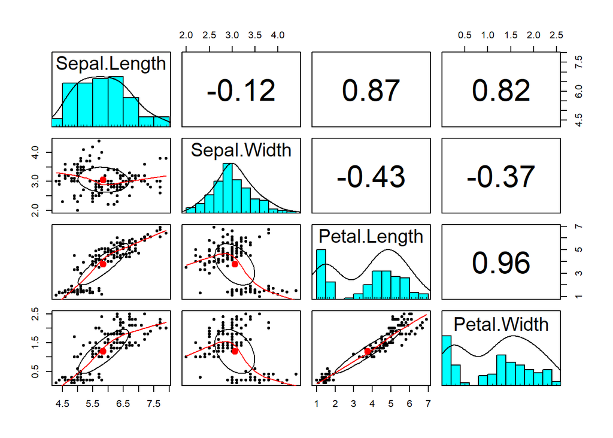

```r
var.type <- sapply(colnames(iris),function(x){class(iris[[x]])})
var <- lapply(unique(var.type),function(x){var.type[var.type==x]})
names(var) <- unique(var.type)

library(psych)
pairs.panels(iris[names(var$numeric)])
```

## List each data type and associated variables

```r
mydata <- read.csv('data/sampledata.csv')

# List out the data type of each variable or column
var.type <- sapply(colnames(mydata), function(x){class(mydata[[x]])}); var.type
```

```
##     Index     State     Y2002     Y2003     Y2004     Y2005     Y2006
##  "factor"  "factor" "integer" "integer" "integer" "integer" "integer"
##     Y2007     Y2008     Y2009     Y2010     Y2011     Y2012     Y2013
## "integer" "integer" "integer" "integer" "integer" "integer" "integer"
##     Y2014     Y2015
## "integer" "integer"
```

```r
# Group variables into respective data types
var <- lapply(unique(var.type), function(x){ names(var.type[var.type==x])})

# Assign a data type as the name of an associated column
names(var) <- unique(var.type);
var$integer
```

```
##  [1] "Y2002" "Y2003" "Y2004" "Y2005" "Y2006" "Y2007" "Y2008" "Y2009"
##  [9] "Y2010" "Y2011" "Y2012" "Y2013" "Y2014" "Y2015"
```

```r
var$factor
```

```
## [1] "Index" "State"
```

```r
# Show all data types and associated variables
for (i in  1:length(var)){ cat(names(var[i]),' = ',names(var[[i]]),'\n') }
```

```
## factor  =
## integer  =
```

## Sampling

```r
# Samepl random n rows
sample_n(mydata[1:5],3)
```

```
##    Index    State   Y2002   Y2003   Y2004
## 1      A  Alabama 1296530 1317711 1118631
## 23     M Michigan 1295635 1149931 1601027
## 28     N Nebraska 1885081 1309769 1425527
```

```r
# Sample random fraction of rows, here 5%
sample_frac(mydata[6:9], 0.05)
```

```
##      Y2005   Y2006   Y2007   Y2008
## 39 1122030 1971479 1563062 1274168
## 14 1261353 1540274 1747614 1871645
## 19 1751920 1233709 1920301 1185085
```

## Eliminating duplicates

```r
# Remove duplicate rows based on all variables
#d1 = distinct(mydata)

# Remove duplicate rows bbased on selected variables
# .keep_all is to retain all other variables in the output data frame
#d2 = distinct(mydata, var1, var2, .keep_all=TRUE)
```

## Queries

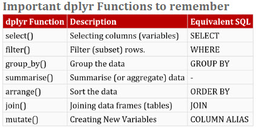

- Data

```r
names(mydata)
```

```
##  [1] "Index" "State" "Y2002" "Y2003" "Y2004" "Y2005" "Y2006" "Y2007"
##  [9] "Y2008" "Y2009" "Y2010" "Y2011" "Y2012" "Y2013" "Y2014" "Y2015"
```

### SELECT variables/columns

```r
head( select(mydata, c('Index', 'Y2006':'Y2008')) )
```

```
##   Index   Y2006   Y2007   Y2008
## 1     A 1107408 1440134 1945229
## 2     A 1861639 1465841 1551826
## 3     A 1102568 1109382 1752886
## 4     A 1669191 1801213 1188104
## 5     C 1735069 1812546 1487315
## 6     C 1871471 1814218 1875146
```

- Select Based on Names

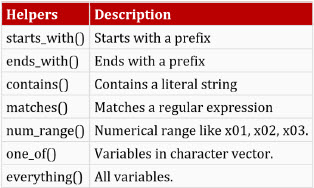

```r
# Drop variables
head( select(mydata, -starts_with('Y')) )
```

```
##   Index      State
## 1     A    Alabama
## 2     A     Alaska
## 3     A    Arizona
## 4     A   Arkansas
## 5     C California
## 6     C   Colorado
```

- Reordering Variables

```r
head( select(mydata, 'State', everything()) )
```

```
##        State Index   Y2002   Y2003   Y2004   Y2005   Y2006   Y2007   Y2008
## 1    Alabama     A 1296530 1317711 1118631 1492583 1107408 1440134 1945229
## 2     Alaska     A 1170302 1960378 1818085 1447852 1861639 1465841 1551826
## 3    Arizona     A 1742027 1968140 1377583 1782199 1102568 1109382 1752886
## 4   Arkansas     A 1485531 1994927 1119299 1947979 1669191 1801213 1188104
## 5 California     C 1685349 1675807 1889570 1480280 1735069 1812546 1487315
## 6   Colorado     C 1343824 1878473 1886149 1236697 1871471 1814218 1875146
##     Y2009   Y2010   Y2011   Y2012   Y2013   Y2014   Y2015
## 1 1944173 1237582 1440756 1186741 1852841 1558906 1916661
## 2 1436541 1629616 1230866 1512804 1985302 1580394 1979143
## 3 1554330 1300521 1130709 1907284 1363279 1525866 1647724
## 4 1628980 1669295 1928238 1216675 1591896 1360959 1329341
## 5 1663809 1624509 1639670 1921845 1156536 1388461 1644607
## 6 1752387 1913275 1665877 1491604 1178355 1383978 1330736
```

- Reanming Variables (Nondestructive)

```r
head( rename(mydata, 'ind'='Index') )
```

```
##   ind      State   Y2002   Y2003   Y2004   Y2005   Y2006   Y2007   Y2008
## 1   A    Alabama 1296530 1317711 1118631 1492583 1107408 1440134 1945229
## 2   A     Alaska 1170302 1960378 1818085 1447852 1861639 1465841 1551826
## 3   A    Arizona 1742027 1968140 1377583 1782199 1102568 1109382 1752886
## 4   A   Arkansas 1485531 1994927 1119299 1947979 1669191 1801213 1188104
## 5   C California 1685349 1675807 1889570 1480280 1735069 1812546 1487315
## 6   C   Colorado 1343824 1878473 1886149 1236697 1871471 1814218 1875146
##     Y2009   Y2010   Y2011   Y2012   Y2013   Y2014   Y2015
## 1 1944173 1237582 1440756 1186741 1852841 1558906 1916661
## 2 1436541 1629616 1230866 1512804 1985302 1580394 1979143
## 3 1554330 1300521 1130709 1907284 1363279 1525866 1647724
## 4 1628980 1669295 1928238 1216675 1591896 1360959 1329341
## 5 1663809 1624509 1639670 1921845 1156536 1388461 1644607
## 6 1752387 1913275 1665877 1491604 1178355 1383978 1330736
```

### Filtering or subsetting

```r
abc <- mydata %>% select(Index, State, Y2002) %>%
filter( Index %in% c('A','C') & Y2002>=1650000 ); abc
```

```
##   Index      State   Y2002
## 1     A    Arizona 1742027
## 2     C California 1685349
```

- The **grepl** function, essentially like ‘**contain**’, is used to search for pattern matching.

```r
# Output only those with 'Ar' in State variable
filter(abc, grepl('Ar',State))
```

```
##   Index   State   Y2002
## 1     A Arizona 1742027
```

## Ordeing

- arrange

```r
mydata %>% select(c(Index,Y2002:Y2004)) %>%  arrange(Index, Y2002) %>% head()
```

```
##   Index   Y2002   Y2003   Y2004
## 1     A 1170302 1960378 1818085
## 2     A 1296530 1317711 1118631
## 3     A 1485531 1994927 1119299
## 4     A 1742027 1968140 1377583
## 5     C 1343824 1878473 1886149
## 6     C 1610512 1232844 1181949
```

## Summarise

- summarise functions like mean, median, etc.

```r
summarise(mydata, Y2015_mean=mean(Y2015), Y2015_median=median(Y2015))
```

```
##   Y2015_mean Y2015_median
## 1    1588297      1627508
```

- summarise_at

```r
# For is.na, mean, median, etc. the examined object is passed in
summarise_at(mydata, vars(Y2014,Y2015), funs(n(),missing=sum(is.na(.)),mean(., na.rm=TRUE),median(., na.rm=TRUE)))
```

```
##   Y2014_n Y2015_n Y2014_missing Y2015_missing Y2014_mean Y2015_mean
## 1      51      51             0             0    1583360    1588297
##   Y2014_median Y2015_median
## 1      1580394      1627508
```

- subtract mean and calculate the variance

```r
set.seed(1-1)
#
eg <- data.frame(X1=sample(1:100,100), X2=runif(100)) %>% summarise_at(vars(X1,X2), function(x){var(x - mean(x))}); eg
```

```
##         X1         X2
## 1 841.6667 0.07324688
```

- summarise_if conditionally

```r
mydata %>% summarise_if(is.numeric, funs(n(),mean, median))
```

```
##   Y2002_n Y2003_n Y2004_n Y2005_n Y2006_n Y2007_n Y2008_n Y2009_n Y2010_n
## 1      51      51      51      51      51      51      51      51      51
##   Y2011_n Y2012_n Y2013_n Y2014_n Y2015_n Y2002_mean Y2003_mean Y2004_mean
## 1      51      51      51      51      51    1566034    1509193    1540555
##   Y2005_mean Y2006_mean Y2007_mean Y2008_mean Y2009_mean Y2010_mean
## 1    1522064    1530969    1553219    1538398    1658519    1504108
##   Y2011_mean Y2012_mean Y2013_mean Y2014_mean Y2015_mean Y2002_median
## 1    1574968    1591135    1530078    1583360    1588297      1584734
##   Y2003_median Y2004_median Y2005_median Y2006_median Y2007_median
## 1      1485909      1522230      1480280      1531641      1563062
##   Y2008_median Y2009_median Y2010_median Y2011_median Y2012_median
## 1      1545621      1658551      1498662      1575533      1643855
##   Y2013_median Y2014_median Y2015_median
## 1      1531212      1580394      1627508
```

- summarise factor variable

```r
summarise_all( mydata['Index'], funs(nlevels(.),nmiss=sum(is.na(.))) )
```

```
##   nlevels nmiss
## 1      19     0
```

## group_by

```r
#names(mydata)
mydata %>% group_by(Index) %>% summarise_at( vars(Y2002:Y2004), funs(n(),mean, median)) %>% head()
```

```
## # A tibble: 6 x 10
##   Index Y2002_n Y2003_n Y2004_n Y2002_mean Y2003_mean Y2004_mean
##   <fct>   <int>   <int>   <int>      <dbl>      <dbl>      <dbl>
## 1 A           4       4       4   1423598.    1810289   1358400.
## 2 C           3       3       3   1546562.    1595708   1652556
## 3 D           2       2       2   1220920     1631207   1540697
## 4 F           1       1       1   1964626     1468852   1419738
## 5 G           1       1       1   1929009     1541565   1810773
## 6 H           1       1       1   1461570     1200280   1213993
## # ... with 3 more variables: Y2002_median <dbl>, Y2003_median <dbl>,
## #   Y2004_median <dbl>
```

```r
# Find the maximums in selcted groups of a variables
mydata %>% select(Index,Y2005, Y2007) %>% filter(Index %in% c('C','F','H')) %>% group_by(Index) %>% summarise(n(), max(Y2005), max(Y2007))
```

```
## # A tibble: 3 x 4
##   Index `n()` `max(Y2005)` `max(Y2007)`
##   <fct> <int>        <dbl>        <dbl>
## 1 C         3      1518933      1976976
## 2 F         1      1362787      1278550
## 3 H         1      1245931      1430465
```

## mutate for creating a new variable

```r
mean(mydata$Y2008)
```

```
## [1] 1538398
```

```r
mydata %>% select(Index,Y2008) %>%
mutate_if(is.numeric,funs('norm'=.-mean(.))) %>% head()
```

```
##   Index   Y2008       norm
## 1     A 1945229  406831.35
## 2     A 1551826   13428.35
## 3     A 1752886  214488.35
## 4     A 1188104 -350293.65
## 5     C 1487315  -51082.65
## 6     C 1875146  336748.35
```

- Ranking among variables

By default, **min_rank()** assigns 1 to the smallest value and high number to the largest value. In case, you need to assign rank 1 to the largest value of a variable, use min_rank(**desc(.)**)

```r
mydata %>% select(Index,State,Y2008:Y2010) %>% mutate_at( vars(Y2008:Y2010), funs(Rank=min_rank(desc(.))) ) %>% arrange(Y2008_Rank) %>%  head()
```

```
##   Index         State   Y2008   Y2009   Y2010 Y2008_Rank Y2009_Rank
## 1     M      Michigan 1990431 1575185 1267626          1         32
## 2     W     Wisconsin 1980167 1901394 1648755          2          9
## 3     M Massachusetts 1978904 1567651 1761048          3         35
## 4     K        Kansas 1949478 1561528 1550433          4         36
## 5     A       Alabama 1945229 1944173 1237582          5          6
## 6     U          Utah 1939284 1915865 1619186          6          8
##   Y2010_Rank
## 1         42
## 2         13
## 3          8
## 4         21
## 5         44
## 6         17
```

```r
mydata %>% group_by(Index) %>% filter(min_rank(desc(Y2015))==1) %>%  select(Index,State,Y2015) %>%  head()
```

```
## # A tibble: 6 x 3
## # Groups:   Index [6]
##   Index State         Y2015
##   <fct> <fct>         <int>
## 1 A     Alaska      1979143
## 2 C     Connecticut 1718072
## 3 D     Delaware    1627508
## 4 F     Florida     1170389
## 5 G     Georgia     1725470
## 6 H     Hawaii      1150882
```

## JOIN

- Demo data sets

```r
df1 = data.frame(
  ID = c(1, 2, 3, 4, 5),
  w = c('a', 'b', 'c', 'd', 'e'),
  x = c(1, 1, 0, 0, 1),
  y = rnorm(5),
  z = letters[1:5])
df1
```

```
##   ID w x          y z
## 1  1 a 1  0.7818592 a
## 2  2 b 1 -0.7767766 b
## 3  3 c 0 -0.6159899 c
## 4  4 d 0  0.0465803 d
## 5  5 e 1 -1.1303858 e
```

```r
df2 = data.frame(
  ID = c(1, 7, 3, 6, 8),
  a = c('z', 'b', 'k', 'd', 'l'),
  b = c(1, 2, 3, 0, 4),
  c = rnorm(5),
  d = letters[2:6])
df2
```

```
##   ID a b          c d
## 1  1 z 1  0.5767188 b
## 2  7 b 2 -1.2807494 c
## 3  3 k 3  1.6254473 d
## 4  6 d 0 -0.5006966 e
## 5  8 l 4  1.6782972 f
```

### Various types of join

- inner_join(x,y,by= )

INNER JOIN returns rows when there is a match in both tables. In this example, we are merging df1 and df2 with ID as common variable (primary key).

```r
inner_join(df1,df2,by="ID")
```

```
##   ID w x          y z a b         c d
## 1  1 a 1  0.7818592 a z 1 0.5767188 b
## 2  3 c 0 -0.6159899 c k 3 1.6254473 d
```

- left_join(x,y,by= )

LEFT JOIN : It returns **all** rows from the left table, **even if there are no matches in the right table**.

```r
left_join(df1,df2,by="ID")
```

```
##   ID w x          y z    a  b         c    d
## 1  1 a 1  0.7818592 a    z  1 0.5767188    b
## 2  2 b 1 -0.7767766 b <NA> NA        NA <NA>
## 3  3 c 0 -0.6159899 c    k  3 1.6254473    d
## 4  4 d 0  0.0465803 d <NA> NA        NA <NA>
## 5  5 e 1 -1.1303858 e <NA> NA        NA <NA>
```

- right_join(x,y,by= )
- full_join(x,y,by= )

full_join() returns all rows and all columns from both x and y.

```r
full_join(df1,df2,by='ID')
```

```
##   ID    w  x          y    z    a  b          c    d
## 1  1    a  1  0.7818592    a    z  1  0.5767188    b
## 2  2    b  1 -0.7767766    b <NA> NA         NA <NA>
## 3  3    c  0 -0.6159899    c    k  3  1.6254473    d
## 4  4    d  0  0.0465803    d <NA> NA         NA <NA>
## 5  5    e  1 -1.1303858    e <NA> NA         NA <NA>
## 6  7 <NA> NA         NA <NA>    b  2 -1.2807494    c
## 7  6 <NA> NA         NA <NA>    d  0 -0.5006966    e
## 8  8 <NA> NA         NA <NA>    l  4  1.6782972    f
```

- semi_join(x,y,by= )

A semi join returns the rows of the first table where it can find a match in the second table.

```r
semi_join(df1,df2,by='ID')
```

```
##   ID w x          y z
## 1  1 a 1  0.7818592 a
## 2  3 c 0 -0.6159899 c
```

- anti-join(x,y,by= )

An anti join returns the rows of the first table where it cannot find a match in the second table.

```r
anti_join(df1,df2,by='ID')
```

```
##   ID w x          y z
## 1  2 b 1 -0.7767766 b
## 2  4 d 0  0.0465803 d
## 3  5 e 1 -1.1303858 e
```

Notice that the results of a semi_join plus the results of an anti_join give the orignial table. So, **regardless of the table contents or how you join them, semi_join(A, B) plus anti_join(A, B) will return A** (though maybe with the rows in a different order).

## Combining data vertically

```r
# Sample data
mtcars$model <- rownames(mtcars)
first <- mtcars[1:3,]
second <- mtcars[2:5,]
```

- **intersect(x,y)** returns rows appear in both, i.e. common to both x and y.

```r
intersect(first,second)
```

```
##    mpg cyl disp  hp drat    wt  qsec vs am gear carb         model
## 1 21.0   6  160 110 3.90 2.875 17.02  0  1    4    4 Mazda RX4 Wag
## 2 22.8   4  108  93 3.85 2.320 18.61  1  1    4    1    Datsun 710
```

- **union(x,y)** returnd rows appear in either or both x and y. Namely, they are all rows from both the tables and removes duplicate records from the combined dataset. By using **union_all** function, it allows duplicate rows in the combined dataset.

```r
union(first,second)
```

```
##    mpg cyl disp  hp drat    wt  qsec vs am gear carb             model
## 1 21.0   6  160 110 3.90 2.620 16.46  0  1    4    4         Mazda RX4
## 2 18.7   8  360 175 3.15 3.440 17.02  0  0    3    2 Hornet Sportabout
## 3 22.8   4  108  93 3.85 2.320 18.61  1  1    4    1        Datsun 710
## 4 21.4   6  258 110 3.08 3.215 19.44  1  0    3    1    Hornet 4 Drive
## 5 21.0   6  160 110 3.90 2.875 17.02  0  1    4    4     Mazda RX4 Wag
```

```r
union_all(first,second)
```

```
##    mpg cyl disp  hp drat    wt  qsec vs am gear carb             model
## 1 21.0   6  160 110 3.90 2.620 16.46  0  1    4    4         Mazda RX4
## 2 21.0   6  160 110 3.90 2.875 17.02  0  1    4    4     Mazda RX4 Wag
## 3 22.8   4  108  93 3.85 2.320 18.61  1  1    4    1        Datsun 710
## 4 21.0   6  160 110 3.90 2.875 17.02  0  1    4    4     Mazda RX4 Wag
## 5 22.8   4  108  93 3.85 2.320 18.61  1  1    4    1        Datsun 710
## 6 21.4   6  258 110 3.08 3.215 19.44  1  0    3    1    Hornet 4 Drive
## 7 18.7   8  360 175 3.15 3.440 17.02  0  0    3    2 Hornet Sportabout
```

- **setdiff(x,y)** returns rows appear in x but not y.

```r
setdiff(first,second)
```

```
##   mpg cyl disp  hp drat   wt  qsec vs am gear carb     model
## 1  21   6  160 110  3.9 2.62 16.46  0  1    4    4 Mazda RX4
```

## IF ELSE

- **if_else**(condition, true, false, missing = NULL)

```r
df <- c(-10,2,NA)
if_else(df<0,'negative','positive',missing='missing value')
```

```
## [1] "negative"      "positive"      "missing value"
```

- Create a new variable with **if_else**

```r
mydf = data.frame(x=c(1:5,NA))
mydf %>% mutate(newvar=if_else(is.na(x),"I am missing", if_else(x==1,"I am one", if_else(x==2,"I am two", if_else(x==3,"I am three","Others")))))
```

```
##    x       newvar
## 1  1     I am one
## 2  2     I am two
## 3  3   I am three
## 4  4       Others
## 5  5       Others
## 6 NA I am missing
```

## SQL-Style CASE WHEN Statement

We can use **case_when()** function to write nested if-else queries. In case_when(), you can use variables directly within case_when() wrapper. TRUE refers to ELSE statement.

**Make sure you set is.na() condition at the beginning in nested if_else. Otherwise, it would not be executed.**

```r
mydf %>% mutate(flag=case_when(
  is.na(x) ~ 'I am missing',
  x==1 ~ 'I am one',
  x==2 ~ 'I am two',
  x==3 ~ 'I am three',
  TRUE ~ 'others'))
```

```
##    x         flag
## 1  1     I am one
## 2  2     I am two
## 3  3   I am three
## 4  4       others
## 5  5       others
## 6 NA I am missing
```

## Automate model building

```r
by_cyl <- group_by(mtcars, cyl)
models <- by_cyl %>% do(mod = lm(mpg ~ disp, data = .))
summarise(models, rsq = summary(mod)$r.squared )
```

```
## # A tibble: 3 x 1
##      rsq
##    <dbl>
## 1 0.648
## 2 0.0106
## 3 0.270
```

```r
models %>% do(data.frame(
  var = names(coef(.$mod)),
  coef(summary(.$mod))
  ))
```

```
## Source: local data frame [6 x 5]
## Groups: <by row>
##
## # A tibble: 6 x 5
##   var          Estimate Std..Error t.value   Pr...t..
## * <fct>           <dbl>      <dbl>   <dbl>      <dbl>
## 1 (Intercept)  40.9        3.59     11.4   0.00000120
## 2 disp         -0.135      0.0332   -4.07  0.00278
## 3 (Intercept)  19.1        2.91      6.55  0.00124
## 4 disp          0.00361    0.0156    0.232 0.826
## 5 (Intercept)  22.0        3.35      6.59  0.0000259
## 6 disp         -0.0196     0.00932  -2.11  0.0568
```

## IF family functions

- select_if

```r
names(mydata)
```

```
##  [1] "Index" "State" "Y2002" "Y2003" "Y2004" "Y2005" "Y2006" "Y2007"
##  [9] "Y2008" "Y2009" "Y2010" "Y2011" "Y2012" "Y2013" "Y2014" "Y2015"
```

```r
select_if(mydata[1:5], is.numeric) %>% head()
```

```
##     Y2002   Y2003   Y2004
## 1 1296530 1317711 1118631
## 2 1170302 1960378 1818085
## 3 1742027 1968140 1377583
## 4 1485531 1994927 1119299
## 5 1685349 1675807 1889570
## 6 1343824 1878473 1886149
```

```r
select_if(mydata[1:5], is.factor) %>% head()
```

```
##   Index      State
## 1     A    Alabama
## 2     A     Alaska
## 3     A    Arizona
## 4     A   Arkansas
## 5     C California
## 6     C   Colorado
```

- summarise_if

```r
summarise_if(mydata, is.factor, funs(nlevels(.)))
```

```
##   Index State
## 1    19    51
```

- mutate_if

```r
mutate_if(mydata[1:5], is.numeric, funs("new" = .* 1000)) %>% head()
```

```
##   Index      State   Y2002   Y2003   Y2004  Y2002_new  Y2003_new
## 1     A    Alabama 1296530 1317711 1118631 1296530000 1317711000
## 2     A     Alaska 1170302 1960378 1818085 1170302000 1960378000
## 3     A    Arizona 1742027 1968140 1377583 1742027000 1968140000
## 4     A   Arkansas 1485531 1994927 1119299 1485531000 1994927000
## 5     C California 1685349 1675807 1889570 1685349000 1675807000
## 6     C   Colorado 1343824 1878473 1886149 1343824000 1878473000
##    Y2004_new
## 1 1118631000
## 2 1818085000
## 3 1377583000
## 4 1119299000
## 5 1889570000
## 6 1886149000
```

- na_if

```r
k <- c("a", "b", "", "d")
na_if(k, "")
```

```
## [1] "a" "b" NA  "d"
```